# Simulation result

Xuelong Wang

2018-06-19

# Reproduce the simulation result from the proposal

The following results basically mimic the results from the proposal

## Simulation setting up

### PCB data with no intercation effect and no interaction in the model

#### simulation procedure

$$y_i = \sum^m_{j = 1}z_j*\beta^{(main)}_j ~+~ \epsilon_i$$
where $\beta_j \sim N(0, 0.5)$ and $z_j$’s are the standardized covariates

#### model

$$y_i = \mu + x_{i1}\beta_1, \dots, + x_im\beta_m + \epsilon_i$$

Where m is the number of covariates.

#### Result

```
##      true_main true_interaction GCTA_main GCTA_interaction  pro_main pro_interaction
## [1,]  2.687376                0 2.5593601                0 2.7110044               0
## [2,]  0.000000                0 0.8092393                0 0.4058923               0
```

- second row is standard deviation

### PCB data with no intercation effect but with interaction in the model

#### simulation procedure

$$y_i = \sum^m_{j = 1}z_j*\beta^{(main)}_j + z_j~+~ \epsilon_i$$
where $\beta_j \sim N(0, 0.5)$ and $z_j$’s are the standardized covariates

#### model

$$y_i = \mu + x_{i1}\beta_1, \dots, + x_im\beta_m + x_{i1}x_{i2}\gamma_{12}, \dots, + x_{i(m-1)}x_{im}\gamma_{(m-1)m} + \epsilon_i$$

#### Result

```
##      true_main true_interaction GCTA_main GCTA_interaction pro_main pro_interaction
## [1,]  2.687376                0 3.1358205     -0.005487239 2.710402      0.00386853
## [2,]  0.000000                0 0.5081987      0.089488682 0.415877      0.27305763
```

### PCB data with intercation effect AND with interaction in the model

#### simulation procedure

$$y_i = \sum^m_{j = 1}z_j*\beta^{(main)}_j + \sum^{m(m-1)/2}_{j=1}z^{(inter)}_j\beta^{(inter)}_j ~+~ \epsilon_i$$
where $\beta^{(main)}_j \sim N(0, 0.5)$ and $z_j$’s are the standardized covariates $\beta^{(inter)}_j \sim N(0, 0.1)$ and $z^{(inter)}_j$ are interaction terms of the standardized covariates

#### model

$$y_i = \mu + x_{i1}\beta_1, \dots, + x_im\beta_m + x_{i1}x_{i2}\gamma_{12}, \dots, + x_{i(m-1)}x_{im}\gamma_{(m-1)m} + \epsilon_i$$

#### Result

```
##      true_main true_interaction GCTA_main GCTA_interaction  pro_main pro_interaction
## [1,]  2.687376         4.291104 2.8521057        5.6127113 2.9875348       0.8293864
## [2,]  0.000000         0.000000 0.5219216        0.9289016 0.4989542       0.4139479
```

### Simulated Independent data with intercation effect AND with interaction in the model

#### simulation procedure

$$y_i = \sum^m_{j = 1}z_j*\beta^{(main)}_j + \sum^{m(m-1)/2}_{j=1}z^{(inter)}_j\beta^{(inter)}_j ~+~ \epsilon_i$$

- $\beta^{(main)}_j \sim N(0, 0.5)$
- $z_j$’s are the standardized covariates
- The original covarites is $X \sim N(0, I_m)$
- $\beta^{(inter)}_j \sim N(0, 0.1)$ and $z^{(inter)}_j$ are interaction terms of the standardized covariates

#### model

$$y_i = \mu + x_{i1}\beta_1, \dots, + x_im\beta_m + x_{i1}x_{i2}\gamma_{12}, \dots, + x_{i(m-1)}x_{im}\gamma_{(m-1)m} + \epsilon_i$$

#### Result

```
##      true_main true_interaction GCTA_main GCTA_interaction  pro_main pro_interaction
## [1,]  3.247473         5.938648 3.6584974         6.832807 3.7823870        6.543834
## [2,]  0.000000         0.000000 0.4686907         1.097281 0.4838153        1.068969
```

### Simulated correlated data with intercation effect AND with interaction in the model

#### simulation procedure

$$y_i = \sum^m_{j = 1}z_j*\beta^{(main)}_j + \sum^{m(m-1)/2}_{j=1}z^{(inter)}_j\beta^{(inter)}_j ~+~ \epsilon_i$$

- $\beta^{(main)}_j \sim N(0, 0.5)$
- $z_j$’s are the standardized covariates
- The original covarites is $X \sim N(0, 2J_m+I_m)$
- $\beta^{(inter)}_j \sim N(0, 0.1)$ and $z^{(inter)}_j$ are interaction terms of the standardized covariates

#### model

$$y_i = \mu + x_{i1}\beta_1, \dots, + x_im\beta_m + x_{i1}x_{i2}\gamma_{12}, \dots, + x_{i(m-1)}x_{im}\gamma_{(m-1)m} + \epsilon_i$$

#### Result

```
##      true_main true_interaction GCTA_main GCTA_interaction  pro_main pro_interaction
## [1,]  2.888376         8.565002  2.534839        12.486556 2.7275643        10.09398
## [2,]  0.000000         0.000000  0.487346         1.014907 0.4969926         1.17584
```

# Simulating different values for $\beta's$

## simulation setting up

The simulation is almost same as previous ones, the only different part is that the true values of $\beta's$ are not fixed. In other words, both $\beta$ and $\epsilon$ are simulated more than once.

More specifically,
$$y_i = \sum^m_{j = 1}z_j*\beta^{(main)}_j + \epsilon_i$$

- simulated 50 for each j, $\beta^{(main)}_j \sim N(0, 0.5)$
- given a set fixed values of $\beta^{(main)}_j$, simulated 5 values for $\epsilon_i$
- similar way is also applied to the interaction case

The reason to also generate simulating different values for $\beta$ is for getting an averaged evaluation of the performance of GCTA and proposed method.

## result

```
##      true_main true_interaction GCTA_main GCTA_interaction  pro_main pro_interaction
## [1,] 2.6873762                0 2.3834395                0 2.8059550               0
## [2,] 0.0000000                0 0.7072900                0 0.4145983               0
## [3,] 1.5461695                0 4.1300709                0 1.3671900               0
## [4,] 0.0000000                0 0.8714383                0 0.2506601               0
## [5,] 0.4947499                0 1.8264133                0 0.5552967               0
## [6,] 0.0000000                0 1.0953575                0 0.3084004               0
```

### Summarized the result

We used MSE to summarized the performance of the across the different $\beta's$ value.

#### MSE of estimated variance

```
## $PCB_no_inter_m
##        GCTA_main GCTA_interaction         pro_main  pro_interaction
##       8.12553362       0.00000000       0.04078901       0.00000000
##
## $PCB_no_inter
##        GCTA_main GCTA_interaction         pro_main  pro_interaction
##      2.230194868      0.007594684      0.038565168      0.281713738
##
## $b_norm_uncorr
##        GCTA_main GCTA_interaction         pro_main  pro_interaction
##        0.1378345        0.2912487        0.1065074        0.2879243
##
## $b_norm_corr
##        GCTA_main GCTA_interaction         pro_main  pro_interaction
##       2.55295495      25.55044421       0.09557645       8.00379538
##
## $PCB_with_inter
##        GCTA_main GCTA_interaction         pro_main  pro_interaction
##         2.255377        14.705123         1.143508        33.923227
```

#### Histogram of each case

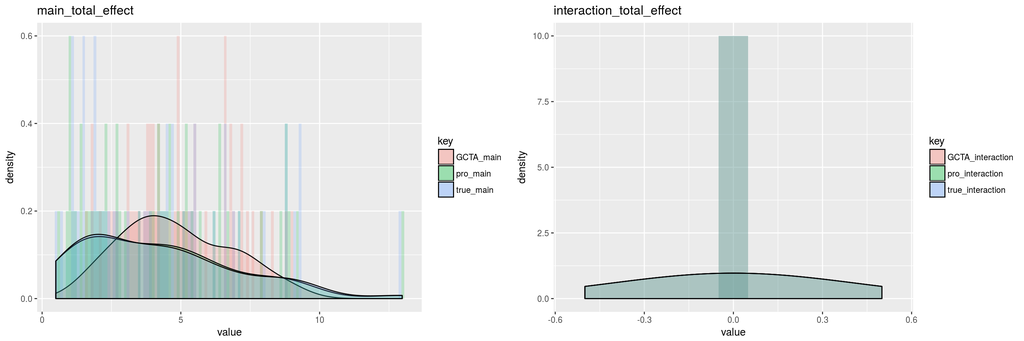

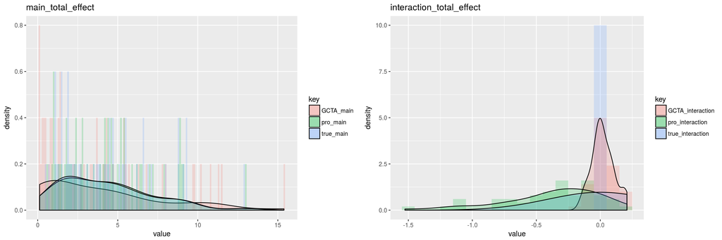

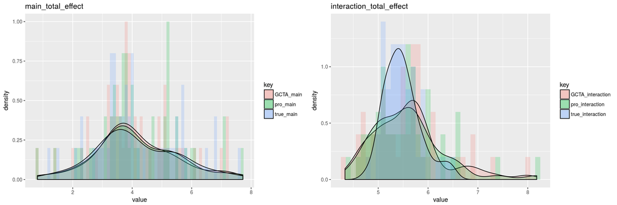

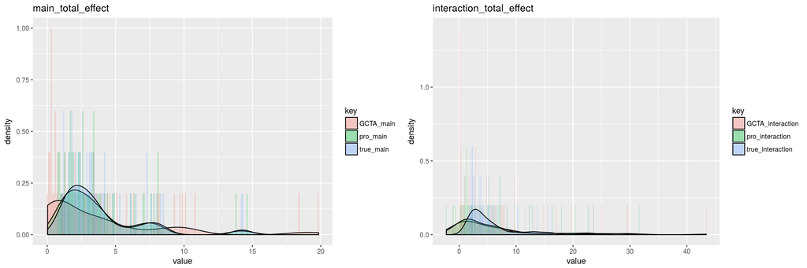

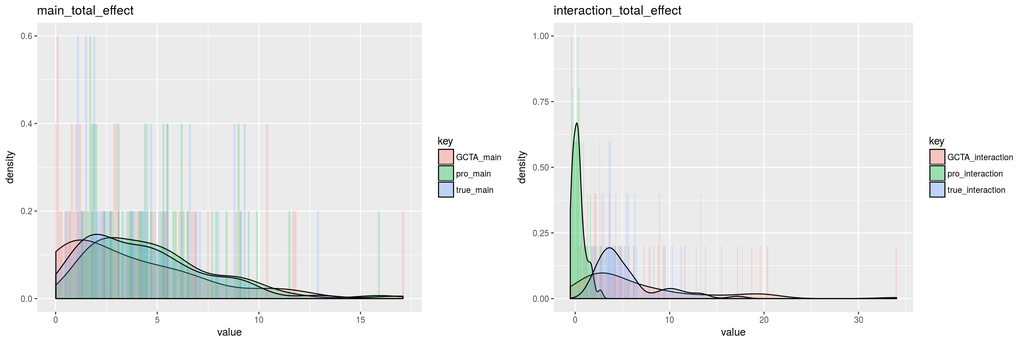

[output not shown]

# Another thought

There is another thought about how to estimate the variance when one considering the interaction terms.

Basically, we combine the main effect and their two-way interaction as the covariates matrix T, and use T as the main effect’s covariates to fit the model and the estimated main effect variance $\hat\sigma_{\beta} = \hat\sigma_{\beta} + \hat\sigma_{\gamma}$

#### simulation procedure

The simulation procedure is same as before

#### model

The only difference is treating both the main effect and interaction effects as main effect and uncorrlated together.

$$y_i = \mu + t_{i1}\beta_1, \dots, + t_im\beta_m + t_{m+1}\beta_{m+1}, \dots, + t_{m+m(m-1)/2}\beta_{m+m(m-1)/2} + \epsilon_i$$

#### MSE of the variance main effect

- Following is the MSE of the main effect by using the fitting method above
- From the theoriatical point of view, this may not be make sence.
- There is an improvement for the proposed method under the dependent normal covariates case.

```
## $PCB_no_inter_m
##  GCTA_main   pro_main
## 23.7436537  0.3679891
##
## $PCB_no_inter
##  GCTA_main   pro_main
## 23.7436537  0.3679891
##
## $b_norm_uncorr
## GCTA_main  pro_main
## 0.4473533 0.3911834
##
## $b_norm_corr
##  GCTA_main   pro_main
## 21.9936479  0.9294216
##
## $PCB_with_inter
## GCTA_main  pro_main
##  72.47582  63.21914
```